# Visualización de Datos

César Alcívar

17/4/2022

```r
if (!require("tidyverse")) library(tidyverse)
```

# Matriz de Correlación

El coeficiente de correlación mide el grado de asociación lineal entre dos variables numéricas. La matriz contiene el coeficiente de correlación entre cada una de las variables numéricas del dataset. A continuación, se muestra la fórmula para obtener el coeficiente de correlación entre dos variables:

$$r = \frac{S_{xy}}{S_xS_y} = \frac{\sum_{i=1}^n (x_i - \bar{x})(y_i - \bar{y})}{\sqrt{\sum_{i=1}^n (x_i - \bar{x})\sum_{i=1}^n (y_i - \bar{y})} }$$

El coeficiente de correlación se caracteriza por $-1\le r \le 1$, de manera que:

- $r = 1$ o $r = -1$ cuando haya una asociación lineal exacta entre las variables.
- 1 < $r$ < 1 cuando la relación entre las variables no sea lineal de forma exacta.
- $0 < | r | < 0.5$ se considera una relación débil.
- $0.8 < | r | < 1$ se considera fuerte, y moderada si tiene otro valor.

# Carga de datos

Para mostrar un gráfico de una matriz de correlación, se utilazará el dataset de la [champions league 2020-2021](https://www.kaggle.com/datasets/mcarujo/uefa-champions-league-20202021).

```r
df_ucl = read_csv('champions_league_2020-2021_results.csv')
head(df_ucl)
```

| stage | date | pens | pens_home_score | pens_away_score | team_name_home | team_name_away | team_home_score | team_away_score | possession_home | possession_away | total_shots_home | total_shots_away | shots_on_target_home | shots_on_target_away | duels_won_home | duels_won_away | prediction_team_home_win | prediction_draw | prediction_team_away_win | location | events_list | lineup_home | lineup_away |
| --- | --- | --- | --- | --- | --- | --- | --- | --- | --- | --- | --- | --- | --- | --- | --- | --- | --- | --- | --- | --- | --- | --- | --- |
| Final | 29.05.2021 | FALSE | FALSE | FALSE | Manchester City | Chelsea | 0 | 1 | 61% | 39% | 7 | 8 | 1 | 2 | 50% | 50% | 55% | 3% | 42% | Estádio Do Dragão | [{'event_team': 'home', 'event_time': " 34' ", 'event_type': 'Yellow card', 'action_player_1': ' Ilkay Gündogan '}, {'event_team': 'away', 'event_time': " 39' ", 'event_type': 'Substitution', 'action_… | [{'player_name': ' Sterling ', 'player_number': ' 7'}, {'player_name': ' De Bruyne ', 'player_number': ' 17'}, {'player_name': ' Mahrez ', 'player_number': ' 26'}, {'player_name': ' Foden ', 'player_n… | [{'player_name': ' Werner ', 'player_number': ' 11'}, {'player_name': ' Mount ', 'player_number': ' 19'}, {'player_name': ' Havertz ', 'player_number': ' 29'}, {'player_name': ' Chilwell ', 'player_nu… |
| Semi-finals second leg | 05.05.2021 | FALSE | FALSE | FALSE | Chelsea | Real Madrid | 2 | 0 | 32% | 68% | 15 | 7 | 5 | 5 | 52% | 49% | 43% | 3% | 54% | Stamford Bridge | [{'event_team': 'home', 'event_time': " 14' ", 'event_type': 'Yellow card', 'action_player_1': ' Jorginho '}, {'event_team': 'home', 'event_time': " 28' ", 'event_type': 'Goal', 'action_player_1': ' T… | [{'player_name': ' Werner ', 'player_number': ' 11'}, {'player_name': ' Havertz ', 'player_number': ' 29'}, {'player_name': ' Chilwell ', 'player_number': ' 21'}, {'player_name': ' Mount ', 'player_nu… | [{'player_name': ' Hazard ', 'player_number': ' 7'}, {'player_name': ' Benzema ', 'player_number': ' 9'}, {'player_name': ' Mendy ', 'player_number': ' 23'}, {'player_name': ' Kroos ', 'player_number'… |
| Semi-finals second leg | 04.05.2021 | FALSE | FALSE | FALSE | Manchester City | PSG | 2 | 0 | 44% | 56% | 12 | 14 | 5 | 0 | 53% | 47% | 44% | 3% | 53% | Etihad Stadium | [{'event_team': 'home', 'event_time': " 11' ", 'event_type': 'Goal', 'action_player_1': ' Riyad Mahrez '}, {'event_team': 'away', 'event_time': " 22' ", 'event_type': 'Yellow card', 'action_player_1':… | [{'player_name': ' Silva ', 'player_number': ' 20'}, {'player_name': ' De Bruyne ', 'player_number': ' 17'}, {'player_name': ' Foden ', 'player_number': ' 47'}, {'player_name': ' Gündogan ', 'player_n… | [{'player_name': ' Neymar ', 'player_number': ' 10'}, {'player_name': ' Icardi ', 'player_number': ' 9'}, {'player_name': ' Di Maria ', 'player_number': ' 11'}, {'player_name': ' Verratti ', 'player_n… |
| Semi-finals first leg | 28.04.2021 | FALSE | FALSE | FALSE | PSG | Manchester City | 1 | 2 | 40% | 60% | 10 | 11 | 4 | 6 | 47% | 53% | 65% | 4% | 31% | Parc des Princes | [{'event_team': 'home', 'event_time': " 15' ", 'event_type': 'Goal', 'action_player_1': ' Marquinhos ', 'action_player_2': ' Angel Di Maria '}, {'event_team': 'away', 'event_time': " 31' ", 'event_typ… | [{'player_name': ' Mbappe ', 'player_number': ' 7'}, {'player_name': ' Verratti ', 'player_number': ' 6'}, {'player_name': ' Neymar ', 'player_number': ' 10'}, {'player_name': ' Di Maria ', 'player_nu… | [{'player_name': ' Foden ', 'player_number': ' 47'}, {'player_name': ' De Bruyne ', 'player_number': ' 17'}, {'player_name': ' Mahrez ', 'player_number': ' 26'}, {'player_name': ' Gündogan ', 'player_… |
| Semi-finals first leg | 27.04.2021 | FALSE | FALSE | FALSE | Real Madrid | Chelsea | 1 | 1 | 51% | 49% | 9 | 11 | 1 | 5 | 49% | 52% | 61% | 4% | 35% | Alfredo Di Stéfano | [{'event_team': 'away', 'event_time': " 14' ", 'event_type': 'Goal', 'action_player_1': ' Christian Pulisic ', 'action_player_2': ' Antonio Rüdiger '}, {'event_team': 'home', 'event_time': " 27' ", 'e… | [{'player_name': ' Junior ', 'player_number': ' 20'}, {'player_name': ' Benzema ', 'player_number': ' 9'}, {'player_name': ' Marcelo ', 'player_number': ' 12'}, {'player_name': ' Kroos ', 'player_numb… | [{'player_name': ' Werner ', 'player_number': ' 11'}, {'player_name': ' Pulisic ', 'player_number': ' 10'}, {'player_name': ' Chilwell ', 'player_number': ' 21'}, {'player_name': ' Mount ', 'player_nu… |
| Quarter-finals second leg | 14.04.2021 | FALSE | FALSE | FALSE | Liverpool | Real Madrid | 0 | 0 | 57% | 43% | 15 | 6 | 4 | 2 | 50% | 50% | 34% | 3% | 63% | Anfield | [{'event_team': 'away', 'event_time': " 25' ", 'event_type': 'Yellow card', 'action_player_1': ' Casemiro '}, {'event_team': 'home', 'event_time': " 25' ", 'event_type': 'Yellow card', 'action_player_… | [{'player_name': ' Mane ', 'player_number': ' 10'}, {'player_name': ' Firmino ', 'player_number': ' 9'}, {'player_name': ' Salah ', 'player_number': ' 11'}, {'player_name': ' Milner ', 'player_number'… | [{'player_name': ' Junior ', 'player_number': ' 20'}, {'player_name': ' Benzema ', 'player_number': ' 9'}, {'player_name': ' Asensio ', 'player_number': ' 11'}, {'player_name': ' Kroos ', 'player_numb… |

A continuación, se muestran las variables del dataset:

```r
str(df_ucl)
```

```
## spec_tbl_df [125 x 24] (S3: spec_tbl_df/tbl_df/tbl/data.frame)
##  $ stage                   : chr [1:125] "Final" "Semi-finals second leg" "Semi-finals second leg" "Semi-finals first leg" ...
##  $ date                    : chr [1:125] "29.05.2021" "05.05.2021" "04.05.2021" "28.04.2021" ...
##  $ pens                    : logi [1:125] FALSE FALSE FALSE FALSE FALSE FALSE ...
##  $ pens_home_score         : logi [1:125] FALSE FALSE FALSE FALSE FALSE FALSE ...
##  $ pens_away_score         : logi [1:125] FALSE FALSE FALSE FALSE FALSE FALSE ...
##  $ team_name_home          : chr [1:125] "Manchester City" "Chelsea" "Manchester City" "PSG" ...
##  $ team_name_away          : chr [1:125] "Chelsea" "Real Madrid" "PSG" "Manchester City" ...
##  $ team_home_score         : num [1:125] 0 2 2 1 1 0 1 0 0 0 ...
##  $ team_away_score         : num [1:125] 1 0 0 2 1 0 2 1 1 2 ...
##  $ possession_home         : chr [1:125] "61%" "32%" "44%" "40%" ...
##  $ possession_away         : chr [1:125] "39%" "68%" "56%" "60%" ...
##  $ total_shots_home        : num [1:125] 7 15 12 10 9 15 10 10 8 12 ...
##  $ total_shots_away        : num [1:125] 8 7 14 11 11 6 17 14 8 6 ...
##  $ shots_on_target_home    : num [1:125] 1 5 5 4 1 4 3 3 1 5 ...
##  $ shots_on_target_away    : num [1:125] 2 5 0 6 5 2 5 5 2 3 ...
##  $ duels_won_home          : chr [1:125] "50%" "52%" "53%" "47%" ...
##  $ duels_won_away          : chr [1:125] "50%" "49%" "47%" "53%" ...
##  $ prediction_team_home_win: chr [1:125] "55%" "43%" "44%" "65%" ...
##  $ prediction_draw         : chr [1:125] "3%" "3%" "3%" "4%" ...
##  $ prediction_team_away_win: chr [1:125] "42%" "54%" "53%" "31%" ...
##  $ location                : chr [1:125] "Estádio Do Dragão" "Stamford Bridge" "Etihad Stadium" "Parc des Princes" ...
##  $ events_list             : chr [1:125] "[{'event_team': 'home', 'event_time': \" 34' \", 'event_type': 'Yellow card', 'action_player_1': ' Ilkay Gündog"| __truncated__ "[{'event_team': 'home', 'event_time': \" 14' \", 'event_type': 'Yellow card', 'action_player_1': ' Jorginho '},"| __truncated_…
##  $ lineup_home             : chr [1:125] "[{'player_name': ' Sterling ', 'player_number': ' 7'}, {'player_name': ' De Bruyne ', 'player_number': ' 17'}, "| __truncated__ "[{'player_name': ' Werner ', 'player_number': ' 11'}, {'player_name': ' Havertz ', 'player_number': ' 29'}, {'p"| __truncated_…
##  $ lineup_away             : chr [1:125] "[{'player_name': ' Werner ', 'player_number': ' 11'}, {'player_name': ' Mount ', 'player_number': ' 19'}, {'pla"| __truncated__ "[{'player_name': ' Hazard ', 'player_number': ' 7'}, {'player_name': ' Benzema ', 'player_number': ' 9'}, {'pla"| __truncated_…
##  - attr(*, "spec")=
##   .. cols(
##   ..   stage = col_character(),
##   ..   date = col_character(),
##   ..   pens = col_logical(),
##   ..   pens_home_score = col_logical(),
##   ..   pens_away_score = col_logical(),
##   ..   team_name_home = col_character(),
##   ..   team_name_away = col_character(),
##   ..   team_home_score = col_double(),
##   ..   team_away_score = col_double(),
##   ..   possession_home = col_character(),
##   ..   possession_away = col_character(),
##   ..   total_shots_home = col_double(),
##   ..   total_shots_away = col_double(),
##   ..   shots_on_target_home = col_double(),
##   ..   shots_on_target_away = col_double(),
##   ..   duels_won_home = col_character(),
##   ..   duels_won_away = col_character(),
##   ..   prediction_team_home_win = col_character(),
##   ..   prediction_draw = col_character(),
##   ..   prediction_team_away_win = col_character(),
##   ..   location = col_character(),
##   ..   events_list = col_character(),
##   ..   lineup_home = col_character(),
##   ..   lineup_away = col_character()
##   .. )
##  - attr(*, "problems")=<externalptr>
```

Se va a medir el coeficiente de correlación solo en la fase de grupos de las siguientes variables:

- `gf` goles a favor.
- `ga` goles en contra
- `possession` porcentaje de posesión del balón en un partido.
- `total_shots` total de disparos.
- `shots_on_target` total de disparos que fueron a la portería.
- `duels_won` porcentaje de regates ganados en un partido.
- `points` puntos obtenidos en la fase de grupos.

```r
summary(as.factor(df_ucl$stage))
```

```
##                     Final   Group stage: Matchday 1   Group stage: Matchday 2
##                         1                        16                        16
##   Group stage: Matchday 3   Group stage: Matchday 4   Group stage: Matchday 5
##                        16                        16                        16
##   Group stage: Matchday 6  Quarter-finals first leg Quarter-finals second leg
##                        16                         4                         4
##     Round of 16 first leg    Round of 16 second leg     Semi-finals first leg
##                         8                         8                         2
##    Semi-finals second leg
##                         2
```

# Preprocesamiento de los Datos

Se crea un dataframe con los resultados de la fase de preprocesamiento de datos.

```r
result <- tibble(
  team_name = '',
  gf = integer(),
  ga = integer(),
  gd = integer(),
  points = integer(),
  possession = numeric(),
  total_shots = integer(),
  shots_on_target = integer(),
  duels_won = numeric(),
  prediction_team_win = numeric(),
  prediction_draw = numeric(),
  where = '',
  stage = ''
)
```

Se crea una función para transformar los datos de tipo carácter que tienen el símbolo de porcentaje al final del texto.

```r
to_numeric_p = function(value) {
  value = as.numeric(str_split(value, '%')[[1]][1])/100
  return(value)
}
```

```r
stages = c("Group stage: Matchday 1", "Group stage: Matchday 2", "Group stage: Matchday 3", "Group stage: Matchday 4", "Group stage: Matchday 5", "Group stage: Matchday 6")

# Se filtran los partidos en la fase de grupos

for(i in stages){
  match_home <- df_ucl %>% filter(stage == i) %>%
    select(
      team_name = team_name_home,
      gf = team_home_score,
      ga = team_away_score,
      possession = possession_home,
      total_shots = total_shots_home,
      shots_on_target = shots_on_target_home,
      duels_won = duels_won_home,
      prediction_team_win = prediction_team_home_win,
      prediction_draw) %>%
    mutate(
      points = if_else(gf == ga, 1, if_else(gf > ga, 3, 0)),
      gd = gf - ga
  )

  match_home$possession = mapply(match_home$possession, FUN=to_numeric_p)
  match_home$duels_won = mapply(match_home$duels_won, FUN=to_numeric_p)
  match_home$prediction_team_win = mapply(match_home$prediction_team_win, FUN=to_numeric_p)
  match_home$prediction_draw = mapply(match_home$prediction_draw, FUN=to_numeric_p)
  match_home$where = 'home'
  match_home$stage = 'GroupStage'

  match_away <- df_ucl %>% filter(stage == i) %>%
    select(
      team_name = team_name_away,
      gf = team_away_score,
      ga = team_home_score,
      possession = possession_away,
      total_shots = total_shots_away,
      shots_on_target = shots_on_target_away,
      duels_won = duels_won_away,
      prediction_team_win = prediction_team_away_win,
      prediction_draw)  %>%
    mutate(
      points = if_else(gf == ga, 1, if_else(gf > ga, 3, 0)),
      gd = gf - ga
  )

  match_away$possession = mapply(match_away$possession, FUN=to_numeric_p)
  match_away$duels_won = mapply(match_away$duels_won, FUN=to_numeric_p)
  match_away$prediction_team_win = mapply(match_away$prediction_team_win, FUN=to_numeric_p)
  match_away$prediction_draw = mapply(match_away$prediction_draw, FUN=to_numeric_p)
  match_away$where = 'away'
  match_away$stage = 'GroupStage'

  result <- add_row(result, match_home)
  result <- add_row(result, match_away)

}


columns = c('gf', 'ga', 'possession', 'total_shots', 'shots_on_target', 'duels_won', 'points')

# Se agrupan los resultados por equipo
result_group <- result %>%  group_by(team_name) %>% summarize(gf = sum(gf), ga = sum(ga), possession= sum(possession), total_shots = sum(total_shots), shots_on_target= sum(shots_on_target), duels_won = sum(duels_won), points = sum(points))

result_group
```

| team_name | gf | ga | possession | total_shots | shots_on_target | duels_won | points |
| --- | --- | --- | --- | --- | --- | --- | --- |
| Ajax | 7 | 7 | 3.40 | 70 | 30 | 2.87 | 7 |
| Atalanta | 10 | 8 | 2.90 | 76 | 37 | 3.26 | 11 |
| Atlético Madrid | 7 | 8 | 3.08 | 79 | 28 | 3.16 | 9 |
| B. M‘Gladbach | 16 | 9 | 2.58 | 66 | 29 | 3.00 | 8 |
| Barcelona | 16 | 5 | 3.78 | 111 | 48 | 3.06 | 15 |
| Bayern Munich | 18 | 5 | 3.69 | 95 | 34 | 2.97 | 16 |
| Borussia Dortmund | 12 | 5 | 3.55 | 84 | 35 | 3.02 | 13 |
| Chelsea | 14 | 2 | 3.30 | 71 | 32 | 3.16 | 14 |
| Club Brugge | 8 | 10 | 3.00 | 56 | 20 | 2.96 | 8 |
| Dynamo Kyiv | 4 | 13 | 2.51 | 44 | 22 | 2.92 | 4 |

[output cut: 22 more lines]

# Gráfico Matriz de Correlación

Antes de presentar el gráfico de la matriz se calcula el coeficiente de correlación entre cada una de las variables. En $R$ se utiliza la función `cor`.

```r
result_matrix <- round(cor(result_group[columns], method = "pearson"), digits = 2)
data.frame(result_matrix)
```

|  | gf | ga | possession | total_shots | shots_on_target | duels_won | points |
| --- | --- | --- | --- | --- | --- | --- | --- |
| gf | 1.00 | -0.59 | 0.53 | 0.65 | 0.75 | 0.43 | 0.82 |
| ga | -0.59 | 1.00 | -0.52 | -0.27 | -0.47 | -0.56 | -0.83 |
| possession | 0.53 | -0.52 | 1.00 | 0.73 | 0.68 | 0.30 | 0.64 |
| total_shots | 0.65 | -0.27 | 0.73 | 1.00 | 0.87 | 0.26 | 0.51 |
| shots_on_target | 0.75 | -0.47 | 0.68 | 0.87 | 1.00 | 0.41 | 0.68 |
| duels_won | 0.43 | -0.56 | 0.30 | 0.26 | 0.41 | 1.00 | 0.58 |
| points | 0.82 | -0.83 | 0.64 | 0.51 | 0.68 | 0.58 | 1.00 |

Una vez caclulado el coeficiente, se instala la librería `corrplot` para mostrar el gráfico matriz de correlación.

```r
if (!require("corrplot")) library(corrplot)
```

A continuación se muestran algunas formas del gráfico matriz de correlación:

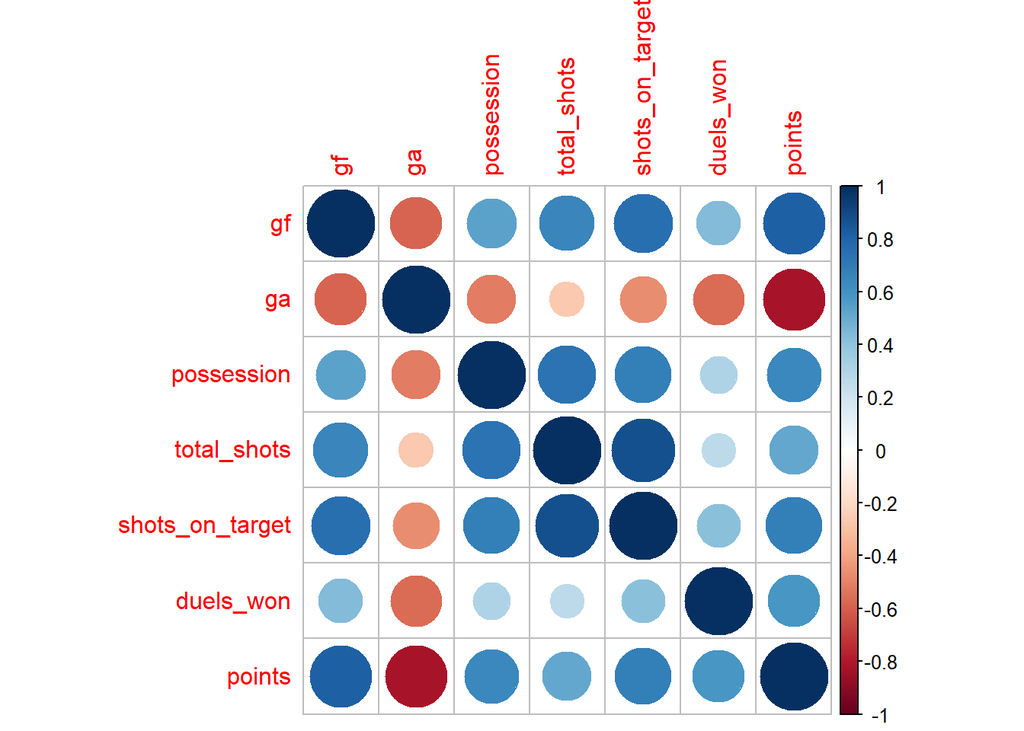

```r
corrplot(result_matrix)
```

[figure not shown]

```r
corrplot(result_matrix,
         method = "shade")
```

[figure not shown]

```r
corrplot(result_matrix,
         method = "shade",
         tl.col = "black",
         addCoef.col = "white")
```

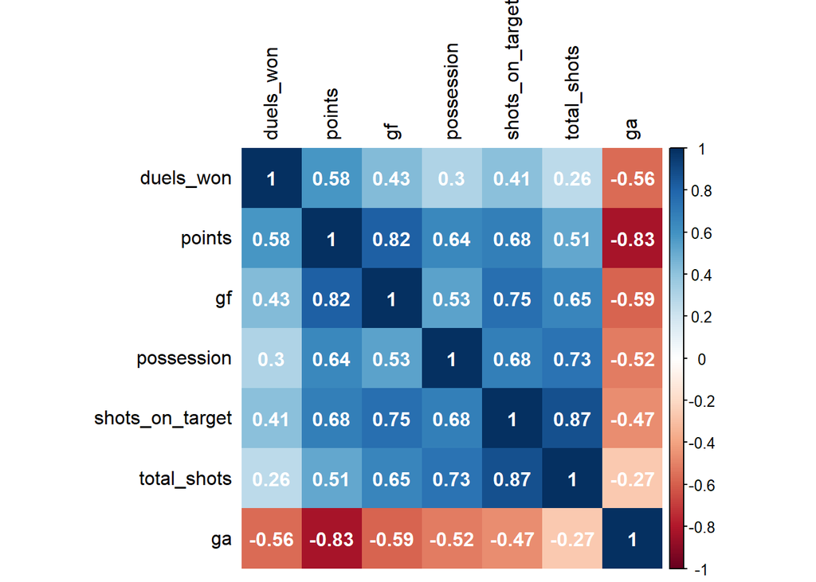

```r
corrplot(result_matrix,
         method = "shade",
         shade.col = NA,
         tl.col = "black",
         addCoef.col = "white",
         order ="AOE")
```

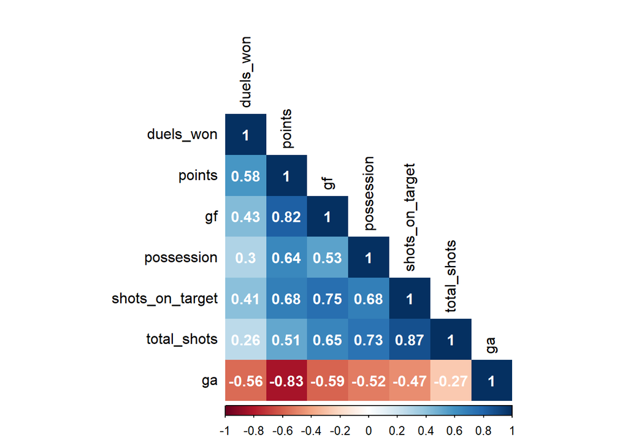

```r
corrplot(result_matrix,
         method = "shade",
         shade.col = NA,
         tl.col = "black",
         addCoef.col = "white",
         order ="AOE",
         type = "low")
```